# Outlier analysis using PCA

Recently I tried to detect outliers in some high-dimensional data to find out more about the dataset. It is quite a common task - you have a dataset at your disposal, and you try to learn more about it. One of the very simplest and fastest ways is to use PCA projection:

- find directions of the largest variance in the data,
- project the high-dimensional points into 2D plane,
- plot them and then
- find records that are not grouped with others visually.

However, when you find these records, you still don't know much about:

- A) why they are actually outlying, and
- B) it can be cumbersome to get the record ID from the visual graph.

In this post I solve the first problem by finding the original dimensions that influence the variance the most, and the latter by making use of some cool matplotlib functionality :)

## A bit of theory

One of the most common way to compute PCA is by using SVD, and take the first two (or three) projections. SVD decomposition is usually noted as

$ \mathbf{A} = \mathbf{U} \mathbf{\Sigma} \mathbf{V}^T $

where $\mathbf{A} \in \mathbb{R}^{n \times m}$ is the original matrix (with many more records $n$ than it's dimension $m$), $\mathbf{U}$ and $\mathbf{V}$ are projecting matrices and $\mathbf{\Sigma}$ is a scaling matrix. There's been much written on these topics, so you can read more about it somewhere else, [Wikipedia has a nice article](https://en.wikipedia.org/wiki/Singular_value_decomposition).

Usually SVD decomposition is implemented in such a way that the diagonal singluar values in $\mathbf{\Sigma}$ and the corresponding columns in $\mathbf{V}$ are sorted by the descending variance value.

To compute which dimensions in the original data have the largest "influence" over the data's variance, you can compare the value sizes in each projection. Let's have projected dimension size $dim=2$:

```
from scipy import linalg
U, S, V = linalg.svd(X, full_matrices=False)
influence = np.abs(np.diag(S[:dim]).dot(V[:dim, :]))
influence /= np.tile(np.sum(influence, axis=1), (influence.shape[1], 1)).T
projected = U[:, :dim]
projected *= S[:dim]
```

So now `influence` contains ratios of influence of each of the original dimensions, and `projected` are the 2D PCA projected points. Neat!

## Real-world example

Let's work with some real data! I took and obfuscated data from some commodity market. The data contains an order book and a table of realized trades. Order book contains records for each timestamp about the top 20 bids/asks - the prices and their cummulative quantities. Trades are a table of matched asks/bids (they are not contained in the order book). To have a clearer idea:

```python
# imports we will need
import pandas as pd
import numpy as np
from scipy import linalg
import matplotlib
import matplotlib.pyplot as plt
from IPython.display import display
# some settings
%matplotlib notebook
pd.options.display.max_rows = 7
pd.options.display.max_columns = None
matplotlib.rcParams['figure.figsize'] = 9, 5

order_book = pd.read_csv('order_book.csv', index_col='timestamp', parse_dates=True)
trades = pd.read_csv('trades.csv', index_col='timestamp', parse_dates=True)
```

```python
order_book
```

| timestamp | bid0Price | bid0Quantity | bid1Price | bid1Quantity | bid2Price | bid2Quantity | bid3Price | bid3Quantity | bid4Price | bid4Quantity | bid5Price | bid5Quantity | bid6Price | bid6Quantity | bid7Price | bid7Quantity | bid8Price | bid8Quantity | bid9Price | bid9Quantity | bid10Price | bid10Quantity | bid11Price | bid11Quantity | bid12Price | bid12Quantity | bid13Price | bid13Quantity | bid14Price | … |
| --- | --- | --- | --- | --- | --- | --- | --- | --- | --- | --- | --- | --- | --- | --- | --- | --- | --- | --- | --- | --- | --- | --- | --- | --- | --- | --- | --- | --- | --- | --- |
| 2016-09-01 00:34:50.718932 | 13.00 | 110 | 12.99 | 200 | 12.98 | 566 | 12.97 | 806 | 12.96 | 14318 | 12.94 | 9460 | 12.91 | 499 | 12.90 | 500 | 12.85 | 70 | 12.84 | 100 | 12.81 | 100 | 12.80 | 778 | 12.75 | 1530 | 12.70 | 276 | 12.65 | … |
| 2016-09-01 00:34:50.746022 | 13.00 | 769 | 12.99 | 200 | 12.98 | 566 | 12.97 | 806 | 12.96 | 14318 | 12.94 | 9460 | 12.91 | 499 | 12.90 | 500 | 12.85 | 70 | 12.84 | 100 | 12.81 | 100 | 12.80 | 778 | 12.75 | 1530 | 12.70 | 276 | 12.65 | … |
| 2016-09-01 00:34:51.074717 | 13.00 | 4177 | 12.99 | 200 | 12.98 | 566 | 12.97 | 806 | 12.96 | 14318 | 12.94 | 9460 | 12.91 | 499 | 12.90 | 500 | 12.85 | 70 | 12.84 | 100 | 12.81 | 100 | 12.80 | 778 | 12.75 | 1530 | 12.70 | 276 | 12.65 | … |
| ... | ... | ... | ... | ... | ... | ... | ... | ... | ... | ... | ... | ... | ... | ... | ... | ... | ... | ... | ... | ... | ... | ... | ... | ... | ... | ... | ... | ... | ... | … |
| 2016-09-01 08:19:59.060005 | 12.85 | 9797 | 12.84 | 2663 | 12.83 | 15677 | 12.82 | 7443 | 12.81 | 3533 | 12.80 | 17274 | 12.79 | 2300 | 12.78 | 31829 | 12.77 | 3365 | 12.76 | 8443 | 12.75 | 12424 | 12.74 | 2900 | 12.73 | 867 | 12.72 | 6652 | 12.71 | … |
| 2016-09-01 08:19:59.060571 | 12.85 | 9797 | 12.84 | 2663 | 12.83 | 15677 | 12.82 | 7443 | 12.81 | 3533 | 12.80 | 32900 | 12.79 | 2300 | 12.78 | 31829 | 12.77 | 3365 | 12.76 | 8443 | 12.75 | 12424 | 12.74 | 2900 | 12.73 | 867 | 12.72 | 6652 | 12.71 | … |
| 2016-09-01 08:19:59.061140 | 12.85 | 9797 | 12.84 | 2663 | 12.83 | 15677 | 12.82 | 7443 | 12.81 | 3533 | 12.80 | 32900 | 12.79 | 2300 | 12.78 | 31829 | 12.77 | 3365 | 12.76 | 8443 | 12.75 | 12424 | 12.74 | 2900 | 12.73 | 867 | 12.72 | 6652 | 12.71 | … |

18564 rows × 80 columns

```python
trades
```

| timestamp | id | side | price | quantity |
| --- | --- | --- | --- | --- |
| 2016-09-01 00:34:47.062570 | 1 | SELL | 13.04 | 30 |
| 2016-09-01 00:34:47.062570 | 2 | SELL | 13.04 | 5 |
| 2016-09-01 00:34:47.062570 | 3 | BUY | 13.04 | 105 |
| ... | ... | ... | ... | ... |
| 2016-09-01 08:19:35.716570 | 2016 | SELL | 12.85 | 1811 |
| 2016-09-01 08:19:44.517570 | 2017 | SELL | 12.85 | 1273 |
| 2016-09-01 08:19:58.781570 | 2018 | BUY | 12.87 | 661 |

2018 rows × 4 columns

Let's plot the top 5 bids and asks in the order book, along with the trades:

```python
# we will use this function again
def plot_table(X, ax):
    plt.subplot(ax)
    for i in range(top):
        ax.plot(order_book.index, order_book["ask%dPrice" % i], color=(0,1-i/top,0))
        ax.plot(order_book.index, order_book["bid%dPrice" % i], color=(1-i/top,0,0))

    buyidx = trades.side == "BUY"
    sellidx = trades.side == "SELL"
    ax.plot(trades.index[buyidx], trades.price[buyidx], 'go')
    ax.plot(trades.index[sellidx], trades.price[sellidx], 'ro')
    plt.ylim([min(order_book["bid%dPrice" % top]),
              max(order_book["ask%dPrice" % top])])
```

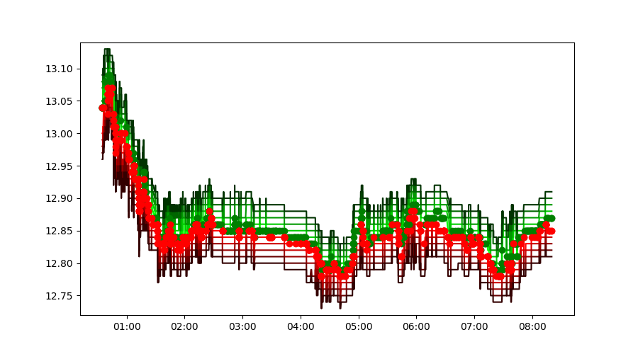

```python
fig = plt.figure()
ax = fig.add_subplot(111)
top = 5
plot_table(None, ax)
```

Nice. But what if I told you, there is an Easter egg hidden in that data? We cannot go through it manually, because it's too large:

```python
print(order_book.shape)
print(trades.shape)
```

```
(18564, 80)
(2018, 4)
```

## Dimensionality reduction tool

This is where dimensionality reduction comes into play. The following class helps a with this problem, the code is somewhat self-explanatory.

The picking magic is done with these lines:

```
scat = ax1.scatter(self.X_red[:, 0], self.X_red[:, 1],
                c=self.y_colors, s=self.s,
                alpha=0.5, picker=True)      # <-- picker=True
...
fig.canvas.mpl_connect('pick_event', onpick) # <-- event handler
```

```python
class DimRedPlot:
    """
    Dimensionality reduction tools for jupyter notebook data analysis
    """

    _select_color = '#FF0000'
    def __init__(self, X, y_colors=None, s=30):
        """
        :param X: original data frame that will be reduced
        :param y_colors: label colors for scatter plot (default gray),
                  cannot use red #FF0000 (or _select_color),
                  that is for selected points only
        :param s: reduced points sizes for scatter plot
        """
        self.X = X
        if y_colors is None:
            self.y_colors = np.array(['#DDDDDD'] * len(X))
        else:
            assert self._select_color not in self.y_colors, \
                '%s color isreserved for selected points only' % self._select_color
        if type(s) is not list:
            self.s = [s] * len(X)
        self.picked_points = []
        self.influence = None

        self.X_red, self.influence = self._pca_red(X)

    def _pca_red(self, X):
        """
        Compute the PCA projection and influence of each dimension to the projection
        """
        U, S, V = linalg.svd(X, full_matrices=False)

        influence = np.abs(np.diag(S[:2]).dot(V[:2, :]))
        # normalize
        influence /= np.tile(np.sum(influence, axis=1), (influence.shape[1], 1)).T

        red = U[:, :2]
        red *= S[:2]

        return red, influence

    def create_plot(self, plot_fn, pick_fn):
        """
        Create interactive plot
        :param plot_fn: callable, with arguments plot_fn(X, subplot_ax2)
        :param pick_fn: callable, with arguments plot_fn(X, subplot_ax2, ind)
                        where ind are selected indices
        """
        fig = plt.figure()
        ax1 = fig.add_subplot(211)
        scat = ax1.scatter(self.X_red[:, 0], self.X_red[:, 1],
                    c=self.y_colors, s=self.s,
                    alpha=0.5, picker=True)
        self.picked_points = []

        ax2 = fig.add_subplot(212)
        plot_fn(self.X, ax2)

        def onpick(event):
            ind = event.ind
            self.picked_points.append(ind)
            self.y_colors[ind] = self._select_color
            scat.set_facecolor(self.y_colors)
            pick_fn(self.X, ax2, ind)
            fig.show()

        fig.canvas.mpl_connect('pick_event', onpick)
        plt.tight_layout()
        fig.show()

    def influence_plot(self):
        """
        Plot each dimension with the amount of it's influence
        """
        _, (ax1, ax2) = plt.subplots(2, 1)
        N = self.influence.shape[1]
        ax1.bar(np.arange(N), self.influence[0, :])
        ax1.set_xticks(np.arange(N))
        ax1.set_xticklabels(self.X.columns,fontsize=10, rotation='vertical')
        ax2.bar(np.arange(N), self.influence[1, :])
        ax2.set_xticks(np.arange(N))
        ax2.set_xticklabels(self.X.columns,fontsize=10, rotation='vertical')
        plt.tight_layout()
        plt.show()

    def outlier_values(self, th= 0.05):
        """
        Return picked outliers with the dimensions that are influential above the threshold
        """
        inf_bool = self.influence > th
        cols = inf_bool[0,:] | inf_bool[1,:]
        points = []
        for add in self.picked_points:
            points += add.tolist()
        return self.X.iloc[points, cols]
```

Let's define one more helper function:

```python
def pick_points(X, ax, ind):
    plt.subplot(ax)
    for i in range(top):
        ax.plot(order_book.index[ind], order_book["ask%dPrice" % i][ind], 'bo')
        ax.plot(order_book.index[ind], order_book["bid%dPrice" % i][ind], 'bo')
```

And now we are ready to setup the PCA plot along the original one:

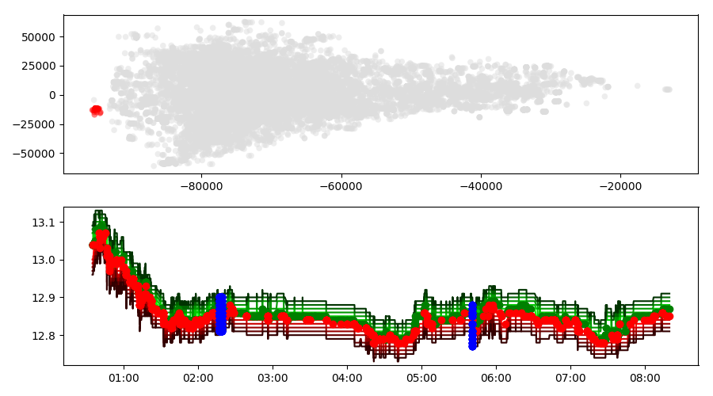

```python
pca_red = DimRedPlot(order_book)
pca_red.create_plot(plot_table, pick_points)
```

By interactively clicking on the points in the PCA plot, they are highlighted in the original plot. Also, they are appended to a list of picked points:

```python
pca_red.picked_points
```

```
[array([ 8835,  8836,  8837,  8838,  8839,  8849,  8850,  8851,  8852,
         8853,  8854,  8855,  8856,  8857,  8858,  8859,  8860,  8861,
         8863,  8864,  8865,  8866,  8867,  8868,  8869,  8870,  8871,
         8872,  8873,  8874,  8875,  8877,  8879, 14113, 14114, 14115,
        14116, 14117], dtype=int32)]
```

To see why they are outlying, we can see the influence of different dimensions:

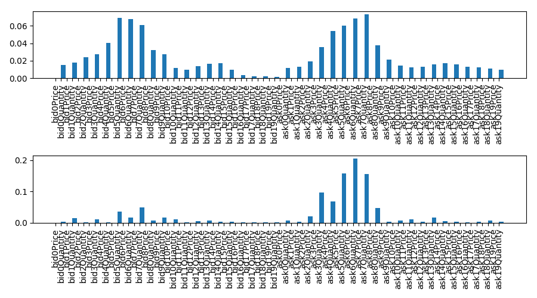

```python
pca_red.influence_plot()
```

So it seems that the most important are the bids/asks quantities, not the prices. Also, more important are the quantities that are not the lowest/highest range (ask0 or bid0), but above them (ask7, bid5). Let's find out what are the most significant values (with influence in percentages above the threshold):

```python
with pd.option_context('display.max_rows', None, 'display.max_columns', None):
    display(pca_red.outlier_values(th=0.05))
```

| timestamp | bid5Quantity | bid6Quantity | bid7Quantity | ask3Quantity | ask4Quantity | ask5Quantity | ask6Quantity | ask7Quantity |
| --- | --- | --- | --- | --- | --- | --- | --- | --- |
| 2016-09-01 02:17:17.406561 | 61872 | 7237 | 51591 | 4768 | 30250 | 49784 | 24233 | 31092 |
| 2016-09-01 02:17:17.412008 | 61872 | 4500 | 51591 | 4768 | 30250 | 49784 | 24233 | 31092 |
| 2016-09-01 02:17:17.414035 | 61872 | 4500 | 51591 | 4768 | 30250 | 49784 | 24233 | 31092 |
| 2016-09-01 02:17:17.414953 | 61872 | 4500 | 51591 | 2052 | 30250 | 49784 | 24233 | 31092 |
| 2016-09-01 02:17:17.415842 | 61872 | 4500 | 51591 | 2052 | 30250 | 52496 | 24233 | 31092 |
| 2016-09-01 02:17:18.490120 | 61872 | 4500 | 67319 | 2052 | 30250 | 34496 | 24233 | 31148 |
| 2016-09-01 02:17:29.019395 | 61872 | 4500 | 67319 | 2052 | 30250 | 34496 | 24233 | 31148 |
| 2016-09-01 02:17:29.020277 | 61872 | 4500 | 67319 | 2052 | 30250 | 34496 | 24233 | 31148 |
| 2016-09-01 02:17:30.811810 | 61872 | 4500 | 67239 | 2052 | 30250 | 34496 | 24233 | 31148 |
| 2016-09-01 02:17:30.812520 | 61872 | 4500 | 67319 | 2052 | 30250 | 34496 | 24233 | 31148 |
| 2016-09-01 02:17:30.943716 | 61872 | 4500 | 67319 | 2052 | 30250 | 34496 | 24233 | 31148 |
| 2016-09-01 02:17:47.687287 | 61872 | 4500 | 67319 | 2052 | 30250 | 34496 | 24233 | 31148 |
| 2016-09-01 02:17:51.465159 | 61872 | 4500 | 67319 | 2052 | 30250 | 34496 | 24233 | 31068 |
| 2016-09-01 02:17:51.466068 | 61872 | 4500 | 67319 | 2052 | 30250 | 34496 | 24233 | 31148 |
| 2016-09-01 02:17:54.729490 | 61872 | 4500 | 67319 | 2052 | 30250 | 34496 | 24233 | 31148 |
| 2016-09-01 02:18:10.439544 | 61872 | 4500 | 67319 | 2052 | 30250 | 34496 | 24233 | 31148 |
| 2016-09-01 02:18:11.565854 | 61792 | 4500 | 67319 | 2052 | 30250 | 34496 | 24233 | 31148 |
| 2016-09-01 02:18:11.567314 | 61872 | 4500 | 67319 | 2052 | 30250 | 34496 | 24233 | 31148 |
| 2016-09-01 02:18:12.921699 | 61872 | 4500 | 67319 | 2052 | 30250 | 34496 | 24233 | 31148 |
| 2016-09-01 02:18:37.605416 | 61872 | 4500 | 67319 | 2052 | 30250 | 34496 | 24233 | 31148 |
| 2016-09-01 02:18:37.606981 | 61872 | 4500 | 67319 | 2052 | 30250 | 34496 | 24233 | 31148 |
| 2016-09-01 02:18:37.634999 | 61872 | 4500 | 67319 | 2052 | 30250 | 34496 | 24233 | 31148 |
| 2016-09-01 02:18:37.636949 | 61872 | 4500 | 67319 | 2052 | 30250 | 34496 | 24233 | 31148 |
| 2016-09-01 02:18:37.669133 | 61872 | 4500 | 67319 | 2052 | 30250 | 34496 | 24233 | 31148 |
| 2016-09-01 02:18:37.681929 | 61872 | 4500 | 67319 | 2052 | 30250 | 34496 | 24233 | 31148 |
| 2016-09-01 02:18:37.715791 | 61872 | 4500 | 67319 | 2052 | 30250 | 34496 | 24233 | 31148 |
| 2016-09-01 02:18:37.787538 | 61872 | 4500 | 67319 | 2052 | 30250 | 34496 | 24233 | 31148 |
| 2016-09-01 02:18:51.699965 | 61872 | 4500 | 67319 | 2052 | 30250 | 34496 | 24233 | 31148 |
| 2016-09-01 02:18:51.700548 | 61872 | 4500 | 67319 | 2052 | 30250 | 34496 | 24233 | 31148 |
| 2016-09-01 02:19:02.299501 | 61872 | 4500 | 67319 | 2052 | 30250 | 34496 | 24233 | 31148 |
| 2016-09-01 02:19:02.320928 | 61872 | 4500 | 67319 | 2052 | 30250 | 34496 | 24233 | 31148 |
| 2016-09-01 02:19:02.323800 | 61872 | 4500 | 67319 | 2052 | 30250 | 34496 | 24233 | 31148 |
| 2016-09-01 02:19:02.341770 | 61872 | 4500 | 67319 | 2052 | 30250 | 34496 | 24233 | 31148 |
| 2016-09-01 05:41:10.424146 | 29880 | 55789 | 5440 | 10983 | 9583 | 5270 | 36206 | 95309 |
| 2016-09-01 05:41:11.095582 | 29880 | 55789 | 5440 | 10983 | 9583 | 5270 | 36206 | 95309 |
| 2016-09-01 05:41:11.096400 | 29880 | 55789 | 5440 | 10983 | 9583 | 5270 | 36206 | 95309 |
| 2016-09-01 05:41:11.096992 | 29880 | 55789 | 5440 | 10983 | 9583 | 5270 | 36206 | 95309 |
| 2016-09-01 05:41:11.097566 | 29880 | 55789 | 5440 | 10983 | 9583 | 5270 | 36206 | 95309 |

## Artificial outliers

Let's try to introduce some artificial outliers, and see if we can detect them backwards :)

```python
import random
n_cols=5
n_outliers=10

total_rows = order_book.shape[0]
total_cols = order_book.shape[1] // 2 # let's affect only quantities, not prices

rows = np.random.randint(0, total_rows-1, n_outliers)
cols = np.random.randint(0, total_cols-1, n_cols) * 2 + 1

print("Influencing %d rows and %d cols" % (n_outliers, n_cols))
print("Rows:")
print(rows)
print("Cols:")
print(cols)

ob_outliers = order_book.copy(deep=True) # so we can repeat this experiment again with differents params
with pd.option_context('display.max_rows', None, 'display.max_columns', None):
    display(ob_outliers.iloc[rows][cols])
```

```
Influencing 10 rows and 5 cols
Rows:
[18005 11224  2641  9379  3014 14177  8685  8594    70  4584]
Cols:
[75 53 21 13 57]
```

| timestamp | ask17Quantity | ask6Quantity | bid10Quantity | bid6Quantity | ask8Quantity |
| --- | --- | --- | --- | --- | --- |
| 2016-09-01 07:48:34.651905 | 910 | 2000 | 1652 | 19696 | 4682 |
| 2016-09-01 04:21:15.879331 | 4700 | 17541 | 280 | 16212 | 6700 |
| 2016-09-01 01:05:17.707427 | 400 | 15415 | 190 | 90 | 1192 |
| 2016-09-01 02:28:49.643137 | 1000 | 35619 | 4985 | 15716 | 15537 |
| 2016-09-01 01:07:25.785003 | 3461 | 2230 | 190 | 18533 | 37290 |
| 2016-09-01 05:44:12.573155 | 2963 | 182 | 13890 | 40024 | 3000 |
| 2016-09-01 02:16:01.026909 | 9540 | 31015 | 3635 | 20138 | 5500 |
| 2016-09-01 02:15:38.187846 | 2245 | 35648 | 2780 | 51591 | 356 |
| 2016-09-01 00:36:20.701235 | 9776 | 4558 | 3886 | 14318 | 394 |
| 2016-09-01 01:17:48.100466 | 200 | 66 | 5713 | 31358 | 22542 |

```python
for row in rows:
    for col in cols:
        ob_outliers.iloc[row, col] = 10 * ob_outliers.iloc[row, col]
```

Let's visualize our data again and pick some outliers:

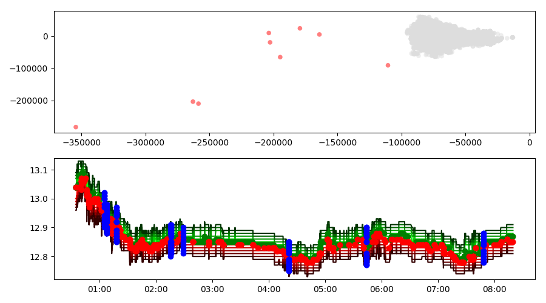

```python
pca_outl= DimRedPlot(ob_outliers)
pca_outl.create_plot(plot_table, pick_points)
```

How well did we do?

```python
import itertools
print(pca_outl.picked_points) # messy... but useful. Each item in the list corresponds to one click.
picked_points = list(itertools.chain(*pca_outl.picked_points)) # flatten out arrays
print('\nPicked %d points:' % len(picked_points))
print(sorted(set(picked_points)))
print('\nOutliers again:')
print(sorted(set(rows)))
```

```
[array([2641], dtype=int32), array([18005], dtype=int32), array([3014], dtype=int32), array([4584], dtype=int32), array([14177], dtype=int32), array([11224], dtype=int32), array([8685, 9379], dtype=int32), array([8685], dtype=int32), array([8594], dtype=int32), array([2641], dtype=int32), array([180…

Picked 16 points:
[2641, 3014, 4584, 8594, 8685, 9379, 11224, 14177, 18005]

Outliers again:
[70, 2641, 3014, 4584, 8594, 8685, 9379, 11224, 14177, 18005]
```

```python
good_picked_points = set(rows) & set(picked_points)
bad_picked_points = set(picked_points) - set(rows)

print("Selected %d good points from %d original outliers" % (len(good_picked_points), n_outliers))
print(good_picked_points)

print("\nSelected %d bad points" % (len(bad_picked_points)))
print(bad_picked_points)
```

```
Selected 9 good points from 10 original outliers
{14177, 9379, 3014, 4584, 8685, 2641, 8594, 18005, 11224}

Selected 0 bad points
set()
```

That's pretty good for a random setting! Well, I have to admit this demo was little bit optimized for the results, because I know PCA tries to find the largest variance - setting values to smaller ones would not yield such nice results :)

Let's try to plot the influence again:

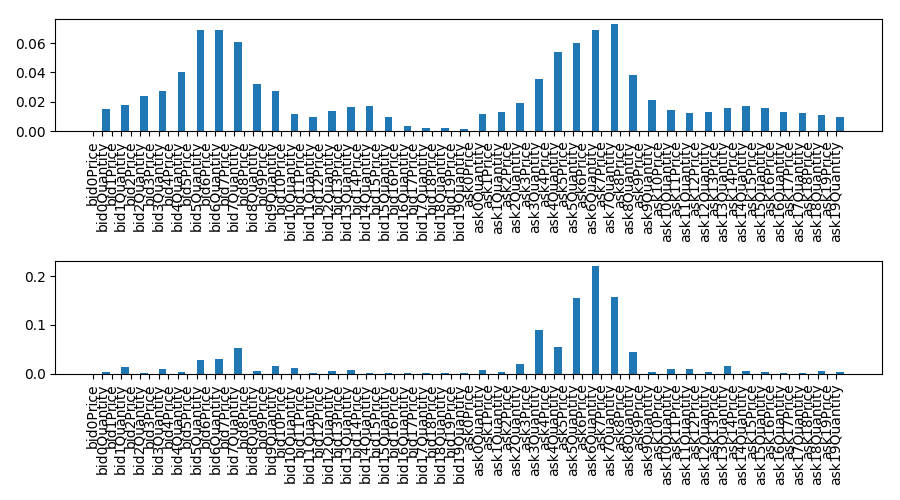

```python
pca_outl.influence_plot()
```

That is not very intelligible. It's hard to compare the results with/without outliers, so let's plot them side by side:

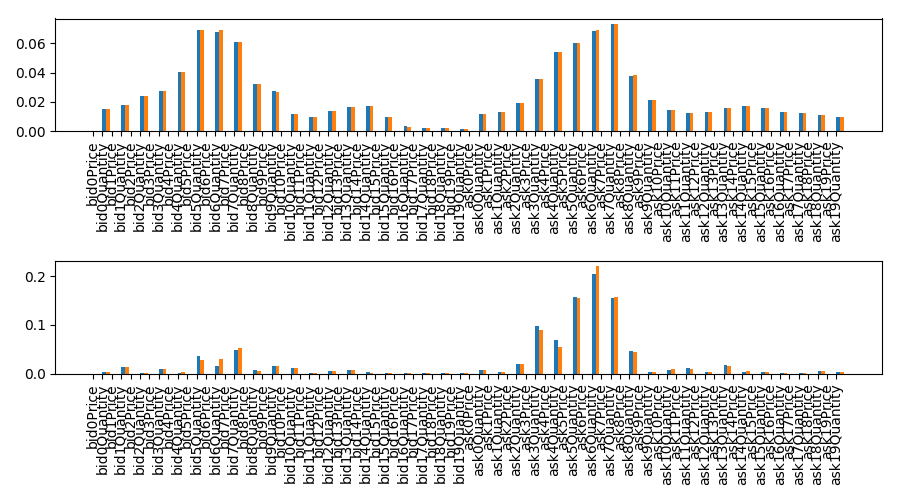

```python
# this is not very nice, but quick&dirty
def plot_influence(X, influence, ax1,ax2, width=0.4, shift_position=0):
    N = influence.shape[1]
    ax1.bar(np.arange(N)+shift_position, influence[0, :], width)
    ax1.set_xticks(np.arange(N))
    ax1.set_xticklabels(X.columns,fontsize=10, rotation='vertical')
    ax2.bar(np.arange(N)+shift_position, influence[1, :], width)
    ax2.set_xticks(np.arange(N))
    ax2.set_xticklabels(X.columns,fontsize=10, rotation='vertical')
    plt.tight_layout()
    plt.show()

_, (ax1, ax2) = plt.subplots(2, 1)
plot_influence(pca_red.X, pca_red.influence, ax1,ax2)
plot_influence(pca_outl.X, pca_outl.influence, ax1,ax2, shift_position=0.4)
```

If you zoom in on some of the columns you can see there are slight differences, but not very many due to the small amount of the introduced outliers.

I hope you enjoyed this article, and see you next time :)

You can download this notebook with the example data from my github:

```python
!git clone https://github.com/michalsustr/blog_examples
!cd OutlierAnalysis
```